# Preliminary Results: Conditional Logistic Regression Model Results

2022 Mpox Multi-Jurisdictional Case-Control VE Public Health Evaluation

Report by Case-Control Unit | VE Team | VTF | 2022 Multinational Monkeypox Response

21 March 2023

## **Report objectives**

1. Match cases to controls by state of residence and within 4-weeks of index event date with a 1 case : up to 4 control ratio.
2. Output conditional logistic regression results using matched data.

```r
# Load packages --------------------------------
  pacman::p_load(here,        # file paths relative to R project root folder
                 rio,         # import/export
                 readxl,      # read excel files
                 tidyverse,    # data management and visualization
                 purrr,        # iteration
                 janitor,      # data management: cleaning and exploring data
                 lubridate,    # working with dates/epiweeks
                 naniar,       # Working with data structures, summaries, and visualizations for Missing Data
                 arsenal,      # provides unctions for large-scale statistical summaries
                 ggsci,        # scientific journal and sci-fi themed color palettes for 'ggplot2'
                 cowplot,      # streamlined plot theme and plot annotations for 'ggplot2'
                 knitr,        # Provides a general-purpose tool for dynamic report generation in R
                 kableExtra,   # simplifies the way to manipulate the HTML or 'LaTeX' codes generated by 'kable()
                 DT,           # provides an R interface to the JavaScript library DataTables
                 gtsummary,    # publication-ready analytical and summary tables
                 tableone,     # Creates 'Table 1', i.e., description of baseline patient characteristics
                 stargazer,    # provides a way to create publication quality tables
                 broom,
                 sjPlot,   # to visualizing mixed-effects models
                 effects,   # to visualizing mixed-effects models
                 lme4,      # "golden standard" for mixed-effects modelling in R (no p-values,
                 lmerTest,  # p-values for MEMs based on the Satterthwaite approximation
                 report,    # mainly for an "report" function
                 emmeans,   # post-hoc analysis
                 MatchIt,
                 survival,
                 splines,
                 knitr,     # beautifying tables
                 sjstats,   # ICC - intraclass-correlation coefficient
                 caret,     # ML, model comparison & utility functions
                 aweek,        # alternative package for working with dates/epiweeks
                 incidence2,   # epicurves of linelist data
                 i2extras,     # supplement to incidence2
                 MMWRweek     # Convert Dates to MMWR Day, Week, and Year


  )

# Global option number format
  options(scipen = 9999)

#GT Table Theme
  theme_gtsummary_journal(journal = "jama")
  theme_gtsummary_compact()
# Helper (custom functions) ------------------------------------------------------------
#This function replicates the SAS proc freq function with the '/ list missing statement'.
#Source: https://github.com/asnr/sas-to-r
pfreq = function(...) {
  dplyr::group_by(...) %>%
    dplyr::summarize(n = n()) %>%
    dplyr::mutate(pct= round(100 * n/sum(n), 1))
  #mutate(Percent=paste0(round(100 * n/sum(n), 1), "%"))
}

# This function helps create consistent values for Yes/No variables.
# by reassigning '2' values a zero.
give_two_a_zero <- function(x){
  x[x == 2 ] <- 0
  x
}


# Source data and define environment variables ---------------------------------------------------------------------

  source("00_REDCap-API-linkage.R", local =knit_global())

  # raw <- here("data", "MultiJurisdictionalM_DATA_2023-03-21_1256.csv") %>%
  # read_csv()

  # Manual review results

    mr <- here("data", "mpoxve_manual_review_combined_aod.xlsx") %>%
      read_excel(sheet = "with_pid") %>%
      rename_with(function(x) paste0("mr_", x), -pid)%>%
      mutate(mr = 1) %>%
      select(mr, pid, everything())

  # Environment variables for Rmarkdown purpose
    # This the date of the earliest symptom per the study protocol

      eligibility_date_v2 <- "19 Aug 2022"

    # This date represent the most recent data transfer from jurisdictions

      redcap_trans_date_v2 <- "20 Mar 2023"

# Tidy data ----------------------------------------------------------------------
mpoxve <- raw %>%
    # Restrict to eligible respondents (i.e., those that passed the eligibility screening)
    filter(inelig_stop ==  1) %>%
    # Restrict to those who have data for relevant eligibility screening questions
    filter(!if_all(c(elig_age, elig_sexuality, elig_gender,
                     elig_gender_msm, elig_sexual_partners,
                     elig_healthcare), is.na)) %>%
    # filter(redcap_data_access_group == "nyc" & consent == 1) %>%
    # select(pid, case_yesno, provider_dx, test_result_date, symptoms_yesno, symptoms_date, control_visit_date, dose1_yesno, dose1_date, dose2_yesno, dose2_date, clinic_yesno, clinic_date) %>%
    #     filter(is.na(case_yesno) & provider_dx == 1)
    left_join(mr, by = c("pid")) %>%
    mutate(#! Variable name key:
               #!  *_cat: indicates a categorical these are flags (0/1)
               #!  *_f: these are flags (0/1)
               #!  *_na: these are also flags but specifically related to missingness (NA = missing in R)
               #!  *_int: these refer to some calculate interval
               #!  pd: an abbreviation for period

            mr = ifelse(is.na(mr), 0, mr),

    #==== General variable cleaning ----
           # Format all yes/no variables with 1(Yes)/2(No) values as 1(Yes)/0(No).
           across(contains(c("elig_age", "elig_gender_msm", "elig_sexual_partners",
                             "elig_healthcare", "first_dose_yesno", "second_dose_yesno",
                             "symptoms_yesno", "provider_dx", "clinic_yesno", "hospitalized",
                             "dose1_yesno", "dose2_yesno"), ignore.case = TRUE), give_two_a_zero),

           # Format all date variables as YYYY-MM-DD
           across(contains("_date", ignore.case = TRUE), ymd),


           # Check the presence of a jurisdiction ID
           juris_detect = case_when(str_detect(pid, "CA_|CO_| CT_|DC_|GA_|LAC_|MD_|MN_|NYC_|NYS_|NYR_|OR_|TN_") ~ 1,
                           TRUE ~ as.numeric(0)),
```

```r
           # Rename REDCap Data Access Group variable and capitalize the letters
           jid = fct_relevel(as_factor(toupper(redcap_data_access_group)),
                             "CA", "LAC", "CO", "CT", "GA", "MD", "MN",
                             "NYS", "NYC", "OR", "TN", "DC"),
          sid = fct_relevel(factor(case_when(jid == "LAC" ~ "CA",
                                             jid %in% c("NYS", "NYC") ~ "NY",
                                             jid == "DC" ~ "MD",
                                             TRUE ~ as.character(jid)))),

    #==== Index date (mpox symptom onset [for cases] or clinic visit date [for controls]) ----

         # Create a study period variable to store mpox symptoms date within 2022-08-19 and most recent data transfer
          eligibility_date = ymd("2022-08-19"),
          redcap_trans_date = ymd("2023-03-20"),

          study_pd_int = interval(eligibility_date, redcap_trans_date),

          index_date = case_when(test_result_date %within% study_pd_int ~ test_result_date,
                                  ((is.na(test_result_date) | #if incomplete or
                                     (test_result_date < eligibility_date)) & # before Aug 19
                                       (symptoms_date %within% study_pd_int)) ~ symptoms_date,
                                  clinic_date %within% study_pd_int ~ clinic_date,
                                  ((is.na(clinic_date) | #if incomplete or
                                      (clinic_date < eligibility_date)) & # before Aug 19
                                       (control_visit_date %within% study_pd_int)) ~ control_visit_date,
                                  TRUE ~ as.Date(NA)),


    #==== Case ascertainment----
          #  2022-01-18 data call decisions:
          #      Cases: Use site test result date, and if missing, use self-reported symptoms date
          #      Controls: Use self-report clinic date, if self-reported missing OR before Aug 19th,
          #                then use the sit- reported clinic date


          # Case status categories
           caco_stat_cat = fct_relevel(as_factor(case_when(

                                                  case_yesno %in% c(1,2) & # Site-reported as confirmed or probable case
                                                    provider_dx == 1 &
                                                    is.na(index_date)      ~ "Case: invalid date",

                                                  case_yesno %in% c(1,2) & # Site-reported as confirmed or probable case
                                                    (provider_dx == 0 &
                                                       clinic_yesno == 1) ~ "Case-site, Control-self",

                                                  case_yesno %in% c(1,2) & # Site-reported as confirmed or probable case
                                                    (provider_dx == 0 &
                                                       clinic_yesno != 1) ~ "Case: self-no dx & clinic visit",

                                                  case_yesno %in% c(1,2) & # Site-reported as confirmed or probable case
                                                    provider_dx == 1 &
                                                    !is.na(index_date)     ~ "Case",

                                                  case_yesno == 3 & # Site-reported as control
                                                    provider_dx == 1     ~ "Control-site, Case-self",

                                                 case_yesno == 3 & # Site-reported as confirmed or probable case
                                                    provider_dx != 1 &
                                                    is.na(index_date) ~ "Control: invalid date",

                                                  case_yesno == 3 & # Site-reported as control
                                                    clinic_yesno != 1 &
                                                    !is.na(index_date)  ~ "Control: no clinic visit-self",

                                                  case_yesno == 3 & # Site-reported as control
                                                   clinic_yesno == 1 &
                                                    #provider_dx != 1 &
                                                    !is.na(index_date)    ~ "Control",


                                                  is.na(case_yesno) ~ "Site-report missing",

                                                  TRUE ~ as.character(NA))),
                              "Case",
                              "Case: invalid date",
                              "Case: self-no dx & clinic visit",
                              "Control",
                              "Control: no clinic visit-self",
                              "Control: invalid date",
                              "Case-site, Control-self",
                              "Control-site, Case-self",
                              "Site-report missing"),

    # binary case status: main analysis
    caco = fct_relevel(as_factor(case_when(caco_stat_cat %in% c("Case",
                                                                "Control-site, Case-self",
                                                                "Case-site, Control-self",
                                                                "Case: self-no dx & clinic visit") ~ "Case",
                                           caco_stat_cat %in% c("Control",

                                                                "Control: no clinic visit-self") ~ "Control",
                                           TRUE ~ as.character(NA))),
                       "Case", "Control"),

    # binary case status: sensitivity analysis, controls who did not self-report as having clinic visit
    caco_sen = fct_relevel(as_factor(case_when(caco_stat_cat %in% c("Case") ~ "Case",
                                               caco_stat_cat %in% c("Control") ~ "Control",
                                               TRUE ~ as.character(NA))),
                           "Case", "Control"),
```

```r
  # Re assign index dates
  index_date = case_when((caco_stat_cat == "Control-site, Case-self" &
                                       (symptoms_date %within% study_pd_int)) ~ symptoms_date,
                                     (caco_stat_cat == "Case-site, Control-self" &
                                       (clinic_date %within% study_pd_int)) ~ test_result_date,
                                     !caco_stat_cat %in%c("Control-site, Case-self", "Case-site, Control-self") ~ index_date,
                                     TRUE ~ as.Date(NA)),

  #==== Vaccination Status ----

         # address invalid dates for self-reported vaccination dates
         d1_yr = case_when(first_dose_date > redcap_trans_date ~ 2022,
                           year(first_dose_date) == 2021 ~ 2022,
                           first_dose_date < ymd("2022-04-30") ~ 2023,
                           TRUE ~ as.numeric(year(first_dose_date))),
         first_dose_date = make_date(year = d1_yr, month = month(first_dose_date), day = day(first_dose_date)),

         d2_yr = case_when(second_dose_date > redcap_trans_date ~ 2022,
                           year(second_dose_date) == 2021 ~ 2022,
                           second_dose_date < ymd("2022-04-30") ~ 2023,
                           TRUE ~ as.numeric(year(second_dose_date))),
         second_dose_date = make_date(year = d2_yr, month = month(second_dose_date), day = day(second_dose_date)),

          # Combine site- and self-reported vaccination dose variables
          vax1_yesno = case_when((is.na(dose1_yesno) & !is.na(first_dose_yesno)) |
                                   (dose1_yesno == 0 & first_dose_yesno == 1)      ~ first_dose_yesno,
                           TRUE ~ as.numeric(dose1_yesno)),

          vax1_date = case_when((!is.na(first_dose_date) & !is.na(second_dose_date) & is.na(dose2_date)) |
                                  (is.na(dose1_date) &
                                  first_dose_yesno == 1 & !is.na(first_dose_date)) ~ first_dose_date,
                           TRUE ~ as.Date(dose1_date)),

          vax1_yrmo = format_ISO8601(vax1_date, precision = "ym"),

          vax2_yesno = case_when((is.na(dose2_yesno) & !is.na(second_dose_yesno)) |
                                   (dose2_yesno == 0 & second_dose_yesno == 1) ~ second_dose_yesno,
                           TRUE ~ as.numeric(dose2_yesno)),

          vax2_date = case_when(is.na(dose2_date) &
                                  second_dose_yesno == 1 & !is.na(second_dose_date) ~ second_dose_date,
                           TRUE ~ as.Date(dose2_date)),

          vax2_yrmo = format_ISO8601(vax2_date, precision = "ym"),

          # Time (days) between index event date and 1st/2nd doses
          dose1index_days = index_date - vax1_date,

          dose2index_days = index_date - vax2_date,

          dose_int        = vax2_date - vax1_date,

          # Vax status: Site
          vax_stat_na = as.character(NA),
          vax_stat_acip = fct_relevel(as_factor(case_when(!is.na(index_date) &
                                                            (vax1_yesno == 0 &  # no documented vaccination OR Post index event vax
                                                                 (vax2_yesno == 0 | is.na(vax2_yesno))) ~ "S1",
                                                          vax1_date >= index_date ~ "S2",
                                                          vax1_yesno == 1 &
                                                             dose1index_days <= 13    ~ "S3",
                                                          (vax1_yesno == 1 & vax2_yesno != 1 &
                                                            dose1index_days >= 14)   ~ "S4",
                                                          (vax1_yesno == 1 & vax2_yesno == 1 &
                                                             dose1index_days >= 14 & dose_int <24) ~ "S5",
                                                          (vax2_yesno == 1 &
                                                             dose1index_days >= 14 &
                                                             dose_int >=24 & dose2index_days < 14) ~ "S6",
                                                     (vax2_yesno == 1 &
                                                        dose_int >=24 & dose2index_days >= 14) ~ "S7",
                                                     TRUE ~ as.character(vax_stat_na))),
                                 "S1", "S2", "S3", "S4", "S5", "S6", "S7"),

        mr_vax_stat_acip = fct_relevel(as_factor(mr_vax_stat_acip),
                                       "S1", "S2", "S3", "S4", "S5", "S6", "S7"),
        mr_review_vax_stat = fct_relevel(as_factor(mr_scenario_r1),
                                       "S1", "S2", "S3", "S4", "S5",
                                       "S6", "S7", "Exclude/investigate"),

        vax_stat_post_acip = fct_relevel(as_factor(case_when(!is.na(index_date) &
                                                            (vax1_yesno == 0 &  # no documented vaccination OR Post index event vax
                                                                 (vax2_yesno == 0 | is.na(vax2_yesno))) ~ "S1",
                                                          vax1_date >= index_date ~ "S2",
                                                          vax1_yesno == 1 &
                                                             dose1index_days <= 13    ~ "S3",
                                                          ((vax1_yesno == 1 & vax2_yesno != 1 &
                                                            dose1index_days >= 14) |
                                                             (vax2_yesno == 1 &
                                                             dose1index_days >= 14 &
                                                             dose_int >=24 & dose2index_days <= 0))   ~ "S4",
                                                          (vax1_yesno == 1 & vax2_yesno == 1 &
                                                             dose1index_days >= 14 & dose_int <24) ~ "S5",
                                                          (vax2_yesno == 1 &
                                                             dose1index_days >= 14 &
                                                             dose_int >=24 & dose2index_days < 14) ~ "S6",
                                                     (vax2_yesno == 1 &
                                                        dose_int >=24 & dose2index_days >= 14) ~ "S7",
                                                     TRUE ~ as.character(vax_stat_na))),
                                 "S1", "S2", "S3", "S4", "S5", "S6", "S7"),
```

```r
          vax_stat = fct_relevel(as_factor(case_when(!is.na(index_date) &
                                                       ((vax1_yesno == 0 &  # no documented vaccination OR Post index event vax
                                                                (vax2_yesno == 0 | is.na(vax2_yesno)))|
                                                          (vax1_date >= index_date)) ~ "Unvaccinated",
                                                     (vax1_yesno == 1 &                   # 1 dose but dose1-index date interval < 14 days
                                                           dose1index_days <= 13)    ~ "PEP",
                                                     ((vax1_yesno == 1 & vax2_yesno != 1 &   # 1 dose partial (1st dose but no 2nd dose)
                                                        dose1index_days >= 14) |
                                                       (vax1_yesno == 1 & vax2_yesno == 1 &  # D1 is <24 days before D2
                                                          dose1index_days >= 14 &
                                                          dose_int <24) |
                                                       (vax2_yesno == 1 &                  # 2 doses partial
                                                          dose1index_days >= 14 &          # (dose 2-index date interval < 14 days )
                                                          dose_int >=24 & dose2index_days < 14)) ~ "Partially vaccinated",
                                                     (vax2_yesno == 1 &
                                                        dose_int >=24 & dose2index_days >= 14) ~ "Fully vaccinated",
                                                     TRUE ~ as.character(vax_stat_na))),
                                 "Fully vaccinated", "Partially vaccinated", "PEP", "Unvaccinated"),

         # Exclude those who had 2 doses but D1 is <24 days before D2 for VE analysis
         vax_stat_ve = case_when((vax1_yesno == 1 & vax2_yesno == 1 &
                                 dose1index_days >= 14 & dose_int <24) | # S5: Partial, D1-D2 interval <24d
                                  vax_stat == "PEP" ~ NA_character_,     # S3: PEP, IE based
                                 TRUE ~ as.character(vax_stat)),

        vax_stat_ve_acip = case_when((vax1_yesno == 1 & vax2_yesno == 1 &
                                   dose1index_days >= 14 & dose_int <24) | # S5: Partial, D1-D2 interval <24d
                                  (vax2_yesno == 1 & dose1index_days >= 14 &
                                     dose_int >=24 & dose2index_days < 14) |   # S6: Partial, D2 <14 before IE,
                                  vax_stat == "PEP" ~ NA_character_,     # S3: PEP, IE based
                                TRUE ~ as.character(vax_stat)),

        # Model 1 (main model):
        vax_stat_ve_main = case_when(vax_stat_post_acip %in% c("S1", "S2") ~ "Unvaccinated",
                                     vax_stat_post_acip %in% c("S4", "S6") ~ "Partially vaccinated",
                                     vax_stat_post_acip %in% c("S7") ~ "Fully vaccinated",
                                  TRUE ~ as.character(NA)),

        # Sensitivity Model 2 (include S6 as fully vaccinated):
        vax_stat_ve_s6full = case_when(vax_stat_post_acip %in% c("S1", "S2") ~ "Unvaccinated",
                                           vax_stat_post_acip %in% c("S4") ~ "Partially vaccinated",
                                           vax_stat_post_acip %in% c("S7", "S6") ~ "Fully vaccinated",
                                        TRUE ~ as.character(NA)),

        #Sensitivity Model 3 (exclude S6 all together)
        vax_stat_ve_s6excl = case_when(vax_stat_post_acip %in% c("S1", "S2") ~ "Unvaccinated",
                                           vax_stat_post_acip %in% c("S4") ~ "Partially vaccinated",
                                           vax_stat_post_acip %in% c("S7") ~ "Fully vaccinated",
                                        TRUE ~ as.character(NA)),

         # Post-exposure prophylaxis
          pep_stat_ve = fct_relevel(as_factor(case_when(why_vax___1 == 1 ~ "PEP-Vaccinated",
                                                        vax_stat == "Unvaccinated" ~ "Unvaccinated",
                                                        TRUE ~as.character(NA))),
                                    "PEP-Vaccinated", "Unvaccinated"),

    #==== Minimum set variables ----
    # Create indicator vars to help flag records missing minimum set of data elements need for VE  variables
          minset_vars = fct_relevel(as_factor(case_when(is.na(case_yesno) |
                                                          is.na(vax1_yesno) |
                                                          (vax1_yesno == 1 & is.na(vax1_date)) |
                                                          (vax1_yesno == 1 & is.na(vax2_yesno)) |
                                                          (vax2_yesno == 1 & is.na(vax2_date)) |
                                                          (!is.na(control_visit_date) &
                                                             !is.na(test_result_date)) | # MD respondents where site-reported test results and control_visit date are available; they people who had test results before Aug 19 as controls.
                                                          #is.na(provider_dx) |
                                                                 #is.na(clinic_yesno) |
                                                                 is.na(index_date) ~ "Incomplete",
                                                               TRUE ~ as.character("Complete"))),
                                          "Complete", "Incomplete"),
    #==== DQ Check: Non-vaccination ----

        # symptom Onset Date vs Test Date (Cases) - Compare symptom onset date to ensure same day as
        #                                           or before positive test result (cases only)
```

```r
         symp_gt_test_date_f = fct_relevel(as_factor(case_when(caco == "Case" & !is.na(symptoms_date) &
                                                                 !is.na(test_result_date) &
                                                                 (symptoms_date >= test_result_date) ~ "Yes",
                                                               caco == "Case" & !is.na(symptoms_date) &
                                                                 !is.na(test_result_date) &
                                                                 (symptoms_date < test_result_date) ~ "No",
                                                               caco == "Control"                     ~ "Not applicable, control",
                                                             TRUE ~ as.character(NA))),
                                         "Yes", "No", "Not applicable, control"),

        # Clinic Visit Date – HD vs Self Report (Controls) - Compare  clinic visit as reported from HD compared to self-report
        #                                                    Flag if (clinic_date - control_visit_date) > +/- 2
         clinic_v_control_date = fct_relevel(as_factor(case_when(!is.na(clinic_date) & !is.na(control_visit_date) &
                                                                   (abs(clinic_date - control_visit_date) > 20) ~ "Abs > 20 days: Yes",
                                                                 !is.na(clinic_date) & !is.na(control_visit_date) &
                                                                   (abs(clinic_date - control_visit_date) <= 20) ~ "Abs > 20 days: No",
                                                                 TRUE ~ as.character(NA))),
                                             "Abs > 20 days: Yes", "Abs > 20 days: No"),
    #==== DQ Check: Vaccination variables ----

          # Dose 1 and Dose 2 Vaccination Interval (self-report) - Flag interval < 24 days and > 24 days to ID implausible intervals
          dose_int_self = ifelse(!is.na(first_dose_date) & !is.na(second_dose_date), second_dose_date - first_dose_date, NA),
          dose_int_cat_self = fct_relevel(as_factor(case_when(first_dose_yesno != 1                                   ~ "Not Vaxed",
                                                                !is.na(first_dose_date) & is.na(second_dose_date)    ~ "Dose #1 only",
                                                                !is.na(first_dose_date) & !is.na(second_dose_date) &
                                                                  ((second_dose_date - first_dose_date) < 24)        ~ "<24 days",
                                                             !is.na(first_dose_date) & !is.na(second_dose_date) &
                                                                  (((second_dose_date - first_dose_date) %in% c(24:28)))  ~ "24-28 days",
                                                                !is.na(first_dose_date) & !is.na(second_dose_date) &
                                                                  ((second_dose_date - first_dose_date) > 28)            ~ ">28 days",
                                                             TRUE ~ as.character(NA))),
                                       "Dose #1 only", "<24 days", "24-28 days", ">28 days", "Not Vaxed"),



          # site-report: Dose 1 and Dose 2 Vaccination Interval - Flag interval < 24 days and > 24 days to ID implausible intervals
         dose_int_site = ifelse(!is.na(dose1_date) & !is.na(dose2_date), dose2_date - dose1_date, NA),
         dose_int_cat_site = fct_relevel(as_factor(case_when(dose1_yesno != 1                             ~ "Not Vaxed",
                                                              !is.na(dose1_date) & is.na(dose2_date)      ~ "Dose #1 only",
                                                              !is.na(dose1_date) & !is.na(dose2_date) &
                                                                ((dose2_date - dose1_date) < 24)          ~ "<24 days",
                                                           !is.na(dose1_date) & !is.na(dose2_date) &
                                                                  (((dose2_date - dose1_date) %in% c(24:28)))  ~ "24-28 days",
                                                              !is.na(dose1_date) & !is.na(dose2_date) &
                                                                ((dose2_date - dose1_date) > 28)          ~ ">28 days",
                                                           TRUE ~ as.character(NA))),
                                         "Dose #1 only", "<24 days", "24-28 days", ">28 days", "Not Vaxed"
                                                           ),
        # Vaccine Dose Number – HD vs Self Report: Compare number of vaccine doses reported from HD compared to self-report
          site_v_self_dose1 = fct_relevel(as_factor(case_when((dose1_yesno == 1 & first_dose_yesno == 1) |
                                                                (dose1_yesno == 0 & first_dose_yesno == 0) ~ "Same",
                                                              (dose1_yesno == 1 & first_dose_yesno == 0)   ~ "Site-Vax",
                                                              (dose1_yesno == 0 & first_dose_yesno == 1)   ~ "Self-Vaxed",
                                                              TRUE ~ as.character(NA))),
                                          "Same", "Site-Vax", "Self-Vaxed"),
          site_v_self_dose2 = fct_relevel(as_factor(case_when((dose2_yesno == 1 & second_dose_yesno == 1) |
                                                                (dose2_yesno == 0 & second_dose_yesno == 0) ~ "Same",
                                                              (dose2_yesno == 1 &
                                                                 (second_dose_yesno == 0 | is.na(second_dose_yesno)))   ~ "Site-Vax",
                                                              ((dose2_yesno == 0 | is.na(dose2_yesno)) &
                                                                 second_dose_yesno == 1)  ~ "Self-Vaxed",
                                                              TRUE ~ as.character(NA))),
                                          "Same", "Site-Vax", "Self-Vaxed"),
```

```r
       # Vaccine Administration Date – HD vs Self Report: Compare dates of vaccination administration between
       #                                                  HD and self-report (add +/- 1 or 2 days)

        site_v_self_vaxdate1 = fct_relevel(as_factor(case_when(!is.na(dose1_date) & !is.na(first_dose_date) &
                                                                 (abs(dose1_date   - first_dose_date) > 2) ~ "Abs > 2: Yes",
                                                               !is.na(dose1_date) & !is.na(first_dose_date) &
                                                                 (abs(dose1_date   - first_dose_date) <= 2) ~ "Abs > 2: No",
                                                               TRUE ~ as.character(NA))),
                                         "Abs > 2: Yes", "Abs > 2: No"),

       site_v_self_vaxdate2 = fct_relevel(as_factor(case_when(!is.na(dose2_date) & !is.na(second_dose_date) &
                                                                (abs(dose2_date   - second_dose_date) > 2) ~ "Abs > 2: Yes",
                                                              !is.na(dose2_date) & !is.na(second_dose_date) &
                                                                (abs(dose2_date   - second_dose_date) <= 2) ~ "Abs > 2: No",
                                                              TRUE ~ as.character(NA))),
                                          "Abs > 2: Yes", "Abs > 2: No"),
    # Prior Smallpox Vaccination Timing flag
           smallpox_birth_f = fct_relevel(as_factor(case_when((priorvax == 1 & (birth_year < priorvax_year)|
                                                                priorvax %in% c(2:3)) ~ "Plausible",
                                                              priorvax == 1 & (birth_year > priorvax_year) ~ "Implausible",
                                                              priorvax == 1 & is.na(birth_year) ~ "birth year missing",
                                                              priorvax == 1 & is.na(priorvax_year) ~ "Vax year missing",
                                                            TRUE ~ as.character(NA))),
                                        "Plausible", "Implausible", "birth year missing", "Vax year missing"),

      #==== Clean analysis variables ----
       # Check to make sure birth year is within range of a person being between 18-49 years old
       #               Invalid birth years/ages should be captured via REDCap checks, except for some unusual
       #                situations which should be reviewed and resolved on a case-by-case basis
              # Calculate age based on birth year and symptom or clinic date
              age = year(index_date) - birth_year,
              # Flag if submitted date– birth_year <18 | > 49 (AOD: we do not have submitted date)
              age_f = fct_relevel(as_factor(case_when(age < 18          ~ "<18",
                                                            age %in% c(18:49) ~ "18-49",
                                                            age > 49          ~ "\u226550",
                                                            TRUE ~ as.character(NA))),
                                        "<18", "18-49", "\u226550"),
              # Age categorical
              age_cat = fct_relevel(as_factor(case_when(age %in% c(18:29) ~ "18-29",
                                                        age %in% c(30:39) ~ "30-39",
                                                        age >=40 ~ "40-49",
                                                            TRUE ~ as.character(NA))),
                                        "18-29", "30-39", "40-49"),



           #categorical race variable
            race_cat = fct_relevel(as_factor(case_when((race___1 == 1 & race___2 == 0 & race___3 == 0 &
                                                         race___4 == 0 & race___5 == 0 & race___6 == 0) ~ "African American or Black",
                                                       (race___1 == 0 & race___2 == 1 & race___3 == 0 &
                                                         race___4 == 0 & race___5 == 0 & race___6 == 0) ~ "White",
                                                       (race___1 == 0 & race___2 == 0 & race___3 == 1 &
                                                          race___4 == 0 & race___5 == 0 & race___6 == 0) ~ "Asian",
                                                       (race___1 == 0 & race___2 == 0 & race___3 == 0 &
                                                          race___4 == 1 & race___5 == 0 & race___6 == 0) ~ "Native Hawaiin/Pacific Islander",
                                                       (race___1 == 0 & race___2 == 0 & race___3 == 0 &
                                                          race___4 == 0 & race___5 == 1 & race___6 == 0) ~ "American Indian/Alaska Native",
                                                       (race___1 == 0 & race___2 == 0 & race___3 == 0 &
                                                          race___4 == 0 & race___5 == 0 & race___6 == 1) ~ "Prefer not to answer",
                                                       (race___1 == 1 | race___2 == 1 | race___3 == 1 |
                                                          race___4 == 1 | race___5 == 1 | race___6 == 1) ~ "Multiracial",
                                                       TRUE ~ NA_character_)),
                                   "African American or Black", "White", "Asian",
                                   "Native Hawaiin/Pacific Islander", "American Indian/Alaska Native", "Prefer not to answer",
                                   "Multiracial"),

            #race-ethnicity: ethnicity (1, Hispanic or Latino | 2, Not Hispanic or Latino | 3, Prefer not to answer)
            race_ethn_cat = fct_relevel(as_factor(case_when(ethnicity == 1 ~ "Hispanic",
                                                        race_cat == "White" ~ "White",
                                                        race_cat == "African American or Black" ~ "Black",
                                                        race_cat == "Asian" ~ "Asian",
                                                        race_cat == "Native Hawaiin/Pacific Islander" ~ "Native Hawaiin/Pacific Islander",
                                                        race_cat == "American Indian/Alaska Native" ~ "American Indian/Alaska Native",
                                                        race_cat == "Multiracial" ~ "Multiracial",
```

```r
                                                        TRUE ~ as.character("Other"))),
                                        "Black", "White", "Hispanic", "Asian",
                                   "Native Hawaiin/Pacific Islander", "American Indian/Alaska Native", "Multiracial", "Other"),

            race_ethn = fct_relevel(as_factor(case_when(ethnicity == 1 ~ "Hispanic",
                                                        race_cat == "White" ~ "White",
                                                        race_cat == "African American or Black" ~ "Black",
                                                        TRUE ~ as.character("Other"))),
                                        "Black", "White", "Hispanic", "Other"),



  # Length of Hospitalization - Examine if length of days of hospitalization is longer than
          #                             the time between illness onset and survey submission
          #                             Flag if hospitalized_days > (submitted date - symptoms_date)
          #!                            AOD: We do not have a submitted date variable at CDC as the sites
          #!                                are not uploading the time stamps. However, only 2 people reported
          #!                                being hospitalized and their days of hospitalization (3 & 13) seem plausible.
         hospitalized_cat = fct_relevel(as_factor(case_when(hospitalized == 0 ~ "No",
                                                            hospitalized == 1 ~ "Yes",
                                                            TRUE ~ as.character(NA))),
                                        "Yes", "No"),
         hospitalized_days_cat = fct_relevel(as_factor(case_when(hospitalized_days == 0         ~ "0",
                                                                  hospitalized_days %in% c(1:7)   ~ "1-7",
                                                                  hospitalized_days %in% c(8:14)  ~ "8-14",
                                                                  hospitalized_days %in% c(15:21) ~ "15-21",
                                                                  hospitalized_days %in% c(22:28) ~ "22-28",
                                                                  hospitalized_days >= 29         ~ "\u226529",
                                                                  TRUE ~ as.character(NA))),
                                              "0", "1-7","8-14", "15-21", "22-28", "22-28", "\u226529"),

          # Number of sexual partners - Examine distribution of number of sexual partners for any implausible values
          #           AOD: what would be considered implausible values?  Range: 0-15 for cases; 0-20 for controls                    #                                categorization included below.

        immunocompromised = fct_relevel(as_factor(case_when(hiv_status == 1 | immune_response ==  1 ~ "Yes",
                                                            TRUE ~ as.character("No"))),
                                        "Yes", "No"),
    # Number of sexual partners - Examine distribution of number of sexual partners for any implausible values
          #                   AOD: what would be considered implausible values?  Range: 0-15 for cases; 0-20 for controls
          sex_part_num = ifelse(caco == "Case", sex_part_num_case,
                               ifelse(caco == "Control", sex_part_num_control, NA)),
          sex_part_num_cat = fct_relevel(as_factor(case_when(sex_part_num == 0 ~ "0",
                                                            sex_part_num == 1 ~ "1",
                                                            sex_part_num == 2 ~ "2",
                                                            sex_part_num == 3 ~ "3",
                                                            sex_part_num >= 4 ~ "\u22654",
                                                            TRUE ~ as.character(NA))),
                                         "0", "1", "2", "3", "\u22654"),
          sex_part_num_mod = fct_relevel(as_factor(case_when(sex_part_num == 0 ~ "0",
                                                            sex_part_num == 1 ~ "1",
                                                            sex_part_num == 2 ~ "2",
                                                            sex_part_num == 3 ~ "3",
                                                            sex_part_num >= 4 ~ "\u22654",
                                                            TRUE ~ as.character("missing"))),
                                         "0", "1", "2", "3", "\u22654", "missing"),



    # Flag those who reported having experienced mpox symptoms and specified one of the listed symptoms
             symptom_type_complete = ifelse(symptoms_yesno == 1 &
                                                 if_any(contains("symptom_type___"), ~ . == 1),
                                               1,
                                               ifelse(symptoms_yesno == 1 &
                                                         if_all(contains("symptom_type___"), ~ . == 0),
                                                       0, NA)),

      # Mpox exposure history: contacts

      close_contact_dx_og = case_when(caco == "Case" & !is.na(contact_mpx_dx_case) ~ contact_mpx_dx_case,
                                     caco == "Case" &
                                       (is.na(contact_mpx_dx_case) &
                                          !is.na(contact_mpx_dx_control)) ~ contact_mpx_dx_control,
                                     caco == "Control" & !is.na(contact_mpx_dx_control) ~ contact_mpx_dx_control,
                                     caco == "Control" &
                                       (is.na(contact_mpx_dx_control) &
                                          !is.na(contact_mpx_dx_case)) ~ contact_mpx_dx_case,
                                     TRUE ~ as.numeric(NA)),
```

```r
      close_contact_dx_cat_og = fct_relevel(as_factor(case_when(close_contact_dx_og == 1 ~ "Yes",
                                                             close_contact_dx_og == 2 ~ "No",
                                                             close_contact_dx_og == 3 ~ "Don't know",
                                                             TRUE ~ as.character(NA))),
                                         "Yes", "No","Don't know"),


        close_contact_dx = case_when(caco == "Case" & !is.na(contact_mpx_dx_case) ~ contact_mpx_dx_case,
                                     caco == "Case" &
                                       (is.na(contact_mpx_dx_case) &
                                          !is.na(contact_mpx_dx_control)) ~ contact_mpx_dx_control,
                                     caco == "Control" & !is.na(contact_mpx_dx_control) ~ contact_mpx_dx_control,
                                     caco == "Control" &
                                       (is.na(contact_mpx_dx_control) &
                                          !is.na(contact_mpx_dx_case)) ~ contact_mpx_dx_case,
                                     TRUE ~ as.numeric(3)),

      close_contact_dx_cat = fct_relevel(as_factor(case_when(close_contact_dx == 1 ~ "Yes",
                                                             close_contact_dx == 2 ~ "No",
                                                             close_contact_dx == 3 ~ "Don't know",
                                                             TRUE ~ as.character(NA))),
                                         "Yes", "No","Don't know"),
  elig_gender_cat = fct_relevel(as_factor(case_when(elig_gender == 1 ~ "Male",
                                                                 elig_gender == 2 ~ "Female",
                                                                 elig_gender == 3 ~ "Transgender male",
                                                                 elig_gender == 4 ~ "Transgender female",
                                                                 elig_gender == 5 ~ "Another gender identity",
                                                                 TRUE ~ as.character(NA))),
                                             "Male", "Female", "Transgender male", "Transgender female",
                                             "Another gender identity"),
               health_ins_cat = fct_relevel(as_factor(case_when(health_ins == 1 ~ "Public",
                                                                health_ins == 2 ~ "Private",
                                                                health_ins == 3 ~ "Public & private",
                                                                health_ins == 4 ~ "None",
                                                                health_ins == 5 ~ "Don't know",
                                                                 TRUE ~ as.character(NA))),
                                             "Public", "Private", "Public & private", "None","Don't know"),
               housing_cat = fct_relevel(as_factor(case_when(homeless == 1 ~ "Homeless shelter",
                                                             homeless == 2 ~ "Unsheltered",
                                                             homeless == 3 ~ "No",
                                                             homeless == 4 ~ "Prefer not to answer",
                                                                 TRUE ~ as.character(NA))),
                                             "Homeless shelter", "Unsheltered", "No", "Prefer not to answer"),
               hiv_status_cat = fct_relevel(as_factor(case_when(hiv_status == 1 ~ "Living with HIV",
                                                                hiv_status == 2 ~ "Not living with HIV",
                                                                hiv_status == 3 ~ "Don't know",
                                                                hiv_status == 4 ~ "Prefer not to answer",
                                                                TRUE ~ as.character(NA))),
                                             "Living with HIV", "Not living with HIV", "Don't know", "Prefer not to answer"),
               hiv_cd4_cat = fct_relevel(as_factor(case_when(hiv_cd4 == 1 ~ "<200",
                                                                hiv_cd4 == 2 ~ "200-500",
                                                                hiv_cd4 == 3 ~ ">500",
                                                                hiv_cd4 == 4 ~ "Don't know",
                                                                hiv_cd4 == 5 ~ "Don't know",
                                                                 TRUE ~ as.character(NA))),
                                         "<200", "200-500", ">500", "Don't know", "Prefer not to answer"),
               hiv_prep_cat = fct_relevel(as_factor(case_when(hiv_prep == 1 ~ "Yes",
                                                                hiv_prep == 2 ~ "No",
                                                                hiv_prep == 3 ~ "Don't know",
                                                                TRUE ~ as.character(NA))),
                                             "Yes", "No", "Don't know"),
               sex_work_cat = fct_relevel(as_factor(case_when(sex_work == 1 ~ "Yes",
                                                                sex_work == 2 ~ "No",
                                                                sex_work == 3 ~ "Don't know",
                                                                TRUE ~ as.character(NA))),
                                             "Yes", "No", "Don't know")

      # time period matching
      # close ------

            ) %>%
        arrange(index_date) %>%
        mutate(index_yrmo = format_ISO8601(index_date, precision = "ym"),
               index_epiyr   = epiyear(index_date),
               index_epiwk   = epiweek(index_date),
               index_epiyrwk_2 = fct_inorder(as_factor(case_when(index_epiyr == 2022 &
                                                                 index_epiwk %in% c(33, 34)~ "2022: 33-34",
                                                               index_epiyr == 2022 &
                                                                 index_epiwk %in% c(35, 36)~ "2022: 35-36",
                                                               index_epiyr == 2022 &
                                                                 index_epiwk %in% c(37, 38)~ "2022: 37-38",
                                                               index_epiyr == 2022 &
                                                                 index_epiwk %in% c(39, 40)~ "2022: 39-40",
                                                               index_epiyr == 2022 &
                                                                 index_epiwk %in% c(41, 42)~ "2022: 41-42",
                                                               index_epiyr == 2022 &
                                                                 index_epiwk %in% c(43, 44)~ "2022: 43-44",
                                                               index_epiyr == 2022 &
                                                                 index_epiwk %in% c(45, 46)~ "2022: 45-46",
                                                               index_epiyr == 2022 &
                                                                 index_epiwk %in% c(47, 48)~ "2022: 47-48",
                                                               index_epiyr == 2022 &
                                                                 index_epiwk %in% c(49, 50)~ "2022: 49-50",
                                                               index_epiyr == 2022 &
                                                                 index_epiwk %in% c(51, 52)~ "2022: 51-52",
                                                               index_epiyr == 2023 &
                                                                 index_epiwk %in% c(1, 2)  ~  "2023: 1-2",
                                                               index_epiyr == 2023 &
                                                                 index_epiwk %in% c(3, 4)  ~  "2023: 3-4",
                                                               index_epiyr == 2023 &
                                                                 index_epiwk %in% c(5, 6)  ~  "2023: 5-6",
                                                               index_epiyr == 2023 &
                                                                 index_epiwk %in% c(7, 8)  ~  "2023: 7-8",
                                                               index_epiyr == 2023 &
                                                                 index_epiwk %in% c(9, 10)  ~ "2023: 9-10",
                                                               index_epiyr == 2023 &
                                                                 index_epiwk %in% c(11, 12)  ~ "2023: 11-12",
                                                               index_epiyr == 2023 &
                                                                 index_epiwk %in% c(13, 14)  ~ "2023: 13-14",
                                                               index_epiyr == 2023 &
                                                                 index_epiwk %in% c(15, 16)  ~ "2023: 15-16"))),
               index_epiyrwk_4 = fct_inorder(as_factor(case_when(index_epiyr == 2022 &
                                                                 index_epiwk %in% c(33, 34, 35, 36)~ "2022: 33-36",
                                                               index_epiyr == 2022 &
                                                                 index_epiwk %in% c(37, 38, 39, 40)~ "2022: 37-40",
                                                               index_epiyr == 2022 &
                                                                 index_epiwk %in% c(41, 42, 43, 44)~ "2022: 41-44",
                                                               index_epiyr == 2022 &
                                                                 index_epiwk %in% c(45, 46, 47, 48)~ "2022: 45-48",
                                                               index_epiyr == 2022 &
                                                                 index_epiwk %in% c(49, 50, 51, 52)~ "2022: 49-52",
                                                               index_epiyr == 2023 &
                                                                 index_epiwk %in% c(1, 2, 3, 4)  ~  "2023: 1-4",
                                                               index_epiyr == 2023 &
                                                                 index_epiwk %in% c(5, 6, 7, 8)  ~  "2023: 5-8",
                                                               index_epiyr == 2023 &
                                                                 index_epiwk %in% c(9, 10, 11, 12)  ~ "2023: 9-12",
                                                               index_epiyr == 2023 &
                                                                 index_epiwk %in% c(13, 14, 15, 16)  ~ "2023: 13-16"))))%>%
  select(pid, jid, everything(), -redcap_data_access_group)
```

```r
# checks ----------
```

## **Distribution of complete minimum set of data elements**

**Table 1. Distribution of respondents with a minimum set of data elements**

```r
mpoxve %>%
  select(sid, minset_vars) %>%
  tbl_summary(
    by = sid,
    label = list(minset_vars ~ "Min data elements")
  )  %>%
  add_n() %>%
  add_overall() %>%
  bold_labels()
```

| **Characteristic** | **N** | **Overall**, N = 1,212<sup>1</sup> | **CA**, N = 264 | **CO**, N = 96 | **CT**, N = 13 | **GA**, N = 206 | **MD**, N = 81 | **MN**, N = 180 | **NY**, N = 205 | **OR**, N = 111 | **TN**, N = 56 |
| --- | --- | --- | --- | --- | --- | --- | --- | --- | --- | --- | --- |
| Min data elements, n (%) | 1,212 |  |  |  |  |  |  |  |  |  |  |
| Complete |  | 1,024 (84) | 221 (84) | 88 (92) | 10 (77) | 176 (85) | 47 (58) | 171 (95) | 179 (87) | 106 (95) | 26 (46) |
| Incomplete |  | 188 (16) | 43 (16) | 8 (8.3) | 3 (23) | 30 (15) | 34 (42) | 9 (5.0) | 26 (13) | 5 (4.5) | 30 (54) |

<sup>1</sup> n (%)

**Figure 1. Missingness patterns across a the set of minimum data elements**

I will look further into the group that is missing vax2_date only (column 2) to see if we can recapture them with help from the sites and reclassify them as having a complete set of minimum data elements.

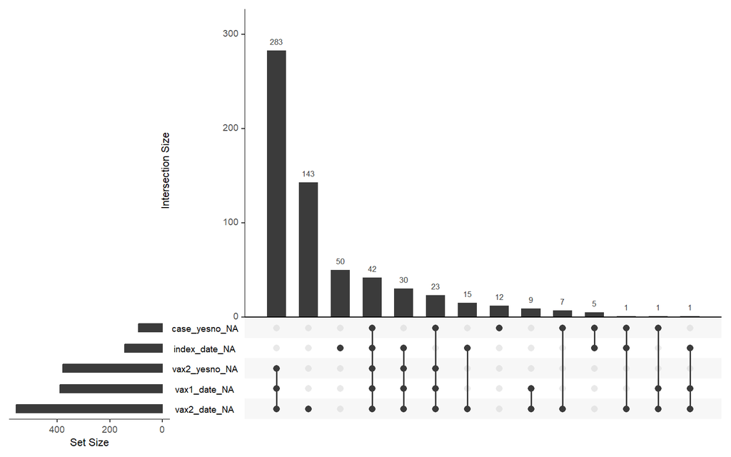

```r
mpoxve %>%
  select(case_yesno, index_date, vax1_yesno, vax1_date, vax2_yesno, vax2_date)%>%
  gg_miss_upset()
```

## **Descriptive statistics: population with complete set of minimum data elements**

**Table 2. Participant characteristics by case status**

```r
mpoxve %>%
  filter(minset_vars == "Complete") %>%
  select(caco, sid, age_cat, race_ethn_cat, elig_gender_cat, health_ins_cat,
         housing_cat, sex_work_cat, hiv_status_cat, hiv_cd4_cat, hiv_prep_cat,
         immunocompromised, close_contact_dx_cat, sex_part_num_cat) %>%
  tbl_summary(
    by = caco,
        label = list(sid ~ "Jurisdiction-States",
                 age_cat ~ "Age categories",
                 race_ethn_cat ~ "Ethnicity, race\U1d43",
                 elig_gender_cat ~ "Gender",
                 health_ins_cat ~ "Insurance Status",
                 housing_cat ~ "Experienced homelessness in past 3 weeks",
                 sex_work_cat ~ "Transactional sex",
                 hiv_status_cat ~ "HIV status",
                 hiv_cd4_cat ~ "CD4 count\U1d47",
                 hiv_prep_cat ~ "HIV PrEP\U1d9c",
                 immunocompromised ~ "Immunocompromised\U1d48",
                 sex_part_num_cat ~ "Number of sexual partners",
                 close_contact_dx_cat ~ "Close contact w/mpox case"),
    missing_text = "Missing"
  )  %>%
  add_n() %>%
  add_overall() %>%
  bold_labels() %>%
  as_gt()%>%
  gt::tab_source_note(gt::md("\U1d43 Hispanic includes self-reported as Hispanic regardless of race.")) %>%
  gt::tab_source_note(gt::md("\U1d47 Denominator is those living with HIV." )) %>%
  gt::tab_source_note(gt::md("\U1d9c Denominator is those who report anything other than living with HIV."))%>%
  gt::tab_source_note(gt::md("\U1d48 HIV or any medical condition other than HIV that weakens your immune response, or use of medicine (other than for HIV) that weakens immune response"))
```

| **Characteristic** | **N** | **Overall**, N = 1,022<sup>1</sup> | **Case**, N = 319 | **Control**, N = 703 |
| --- | --- | --- | --- | --- |
| Jurisdiction-States, n (%) | 1,022 |  |  |  |
| CA |  | 221 (22) | 79 (25) | 142 (20) |
| CO |  | 88 (8.6) | 20 (6.3) | 68 (9.7) |
| CT |  | 10 (1.0) | 7 (2.2) | 3 (0.4) |
| GA |  | 176 (17) | 73 (23) | 103 (15) |
| MD |  | 46 (4.5) | 39 (12) | 7 (1.0) |
| MN |  | 170 (17) | 29 (9.1) | 141 (20) |
| NY |  | 179 (18) | 44 (14) | 135 (19) |
| OR |  | 106 (10) | 17 (5.3) | 89 (13) |
| TN |  | 26 (2.5) | 11 (3.4) | 15 (2.1) |
| Age categories, n (%) | 1,022 |  |  |  |
| 18-29 |  | 278 (27) | 75 (24) | 203 (29) |
| 30-39 |  | 495 (48) | 152 (48) | 343 (49) |
| 40-49 |  | 249 (24) | 92 (29) | 157 (22) |
| Ethnicity, raceᵃ, n (%) | 1,022 |  |  |  |
| Black |  | 197 (19) | 84 (26) | 113 (16) |
| White |  | 443 (43) | 100 (31) | 343 (49) |
| Hispanic |  | 270 (26) | 103 (32) | 167 (24) |
| Asian |  | 44 (4.3) | 8 (2.5) | 36 (5.1) |
| Native Hawaiin/Pacific Islander |  | 4 (0.4) | 3 (0.9) | 1 (0.1) |
| American Indian/Alaska Native |  | 6 (0.6) | 3 (0.9) | 3 (0.4) |
| Multiracial |  | 40 (3.9) | 10 (3.1) | 30 (4.3) |
| Other |  | 18 (1.8) | 8 (2.5) | 10 (1.4) |
| Gender, n (%) | 1,022 |  |  |  |
| Male |  | 926 (91) | 300 (94) | 626 (89) |
| Female |  | 0 (0) | 0 (0) | 0 (0) |
| Transgender male |  | 7 (0.7) | 1 (0.3) | 6 (0.9) |
| Transgender female |  | 25 (2.4) | 6 (1.9) | 19 (2.7) |
| Another gender identity |  | 64 (6.3) | 12 (3.8) | 52 (7.4) |
| Insurance Status, n (%) | 1,018 |  |  |  |
| Public |  | 317 (31) | 106 (33) | 211 (30) |
| Private |  | 519 (51) | 163 (51) | 356 (51) |
| Public & private |  | 28 (2.8) | 10 (3.1) | 18 (2.6) |
| None |  | 136 (13) | 34 (11) | 102 (15) |
| Don't know |  | 18 (1.8) | 5 (1.6) | 13 (1.9) |
| Missing |  | 4 | 1 | 3 |
| Experienced homelessness in past 3 weeks, n (%) | 1,011 |  |  |  |
| Homeless shelter |  | 8 (0.8) | 6 (1.9) | 2 (0.3) |
| Unsheltered |  | 41 (4.1) | 20 (6.3) | 21 (3.0) |
| No |  | 943 (93) | 282 (89) | 661 (95) |
| Prefer not to answer |  | 19 (1.9) | 8 (2.5) | 11 (1.6) |
| Missing |  | 11 | 3 | 8 |
| Transactional sex, n (%) | 1,018 |  |  |  |
| Yes |  | 52 (5.1) | 28 (8.8) | 24 (3.4) |
| No |  | 946 (93) | 284 (89) | 662 (95) |
| Don't know |  | 20 (2.0) | 7 (2.2) | 13 (1.9) |
| Missing |  | 4 | 0 | 4 |
| HIV status, n (%) | 1,019 |  |  |  |
| Living with HIV |  | 304 (30) | 144 (45) | 160 (23) |
| Not living with HIV |  | 686 (67) | 159 (50) | 527 (75) |
| Don't know |  | 12 (1.2) | 6 (1.9) | 6 (0.9) |
| Prefer not to answer |  | 17 (1.7) | 9 (2.8) | 8 (1.1) |
| Missing |  | 3 | 1 | 2 |
| CD4 countᵇ, n (%) | 303 |  |  |  |
| <200 |  | 62 (20) | 36 (25) | 26 (16) |
| 200-500 |  | 49 (16) | 23 (16) | 26 (16) |
| >500 |  | 106 (35) | 46 (32) | 60 (38) |
| Don't know |  | 86 (28) | 38 (27) | 48 (30) |
| Missing |  | 719 | 176 | 543 |
| HIV PrEPᶜ, n (%) | 714 |  |  |  |
| Yes |  | 464 (65) | 101 (58) | 363 (67) |
| No |  | 249 (35) | 72 (41) | 177 (33) |
| Don't know |  | 1 (0.1) | 1 (0.6) | 0 (0) |
| Missing |  | 308 | 145 | 163 |
| Immunocompromisedᵈ, n (%) | 1,022 | 338 (33) | 155 (49) | 183 (26) |
| Close contact w/mpox case, n (%) | 1,022 |  |  |  |
| Yes |  | 107 (10) | 84 (26) | 23 (3.3) |
| No |  | 591 (58) | 92 (29) | 499 (71) |
| Don't know |  | 324 (32) | 143 (45) | 181 (26) |
| Number of sexual partners, n (%) | 894 |  |  |  |
| 0 |  | 38 (4.3) | 18 (6.0) | 20 (3.4) |
| 1 |  | 188 (21) | 61 (20) | 127 (21) |
| 2 |  | 210 (23) | 70 (23) | 140 (23) |
| 3 |  | 158 (18) | 60 (20) | 98 (16) |
| ≥4 |  | 300 (34) | 89 (30) | 211 (35) |
| Missing |  | 128 | 21 | 107 |

ᵃ Hispanic includes self-reported as Hispanic regardless of race.  
ᵇ Denominator is those living with HIV.  
ᶜ Denominator is those who report anything other than living with HIV.  
ᵈ HIV or any medical condition other than HIV that weakens your immune response, or use of medicine (other than for HIV) that weakens immune response  
<sup>1</sup> n (%)

**Table 3. Participant characteristics by vaccination status as defined for the main model** *Note* The N decreased in this table because we drop s3 and s5 from vaccination status variable in the main model.

```r
mpoxve %>%
  filter(minset_vars == "Complete") %>%
  select(vax_stat_ve_main, sid, age_cat, race_ethn_cat, elig_gender_cat, health_ins_cat,
         housing_cat, sex_work_cat, hiv_status_cat, hiv_cd4_cat, hiv_prep_cat,
         immunocompromised, close_contact_dx_cat, sex_part_num_cat) %>%
  tbl_summary(
    by = vax_stat_ve_main,
    label = list(sid ~ "Jurisdiction-States",
                 age_cat ~ "Age categories",
                 race_ethn_cat ~ "Ethnicity, race\U1d43",
                 elig_gender_cat ~ "Gender",
                 health_ins_cat ~ "Insurance Status",
                 housing_cat ~ "Experienced homelessness in past 3 weeks",
                 sex_work_cat ~ "Transactional sex",
                 hiv_status_cat ~ "HIV status",
                 hiv_cd4_cat ~ "CD4 count\U1d47",
                 hiv_prep_cat ~ "HIV PrEP\U1d9c",
                 immunocompromised ~ "Immunocompromised\U1d48",
                 sex_part_num_cat ~ "Number of sexual partners",
                 close_contact_dx_cat ~ "Close contact w/mpox case"),
    missing_text = "Missing"
  )  %>%
  add_n() %>%
  add_overall() %>%
  bold_labels() %>%
  as_gt()%>%
  gt::tab_source_note(gt::md("\U1d43 Hispanic includes self-reported as Hispanic regardless of race.")) %>%
  gt::tab_source_note(gt::md("\U1d47 Denominator is those living with HIV." )) %>%
  gt::tab_source_note(gt::md("\U1d9c Denominator is those who report anything other than living with HIV."))%>%
  gt::tab_source_note(gt::md("\U1d48 HIV or any medical condition other than HIV that weakens your immune response, or use of medicine (other than for HIV) that weakens immune response"))
```

| **Characteristic** | **N** | **Overall**, N = 947<sup>1</sup> | **Fully vaccinated**, N = 257 | **Partially vaccinated**, N = 285 | **Unvaccinated**, N = 405 |
| --- | --- | --- | --- | --- | --- |
| Jurisdiction-States, n (%) | 947 |  |  |  |  |
| CA |  | 208 (22) | 68 (26) | 54 (19) | 86 (21) |
| CO |  | 83 (8.8) | 32 (12) | 20 (7.0) | 31 (7.7) |
| CT |  | 10 (1.1) | 0 (0) | 1 (0.4) | 9 (2.2) |
| GA |  | 161 (17) | 28 (11) | 38 (13) | 95 (23) |
| MD |  | 44 (4.6) | 17 (6.6) | 7 (2.5) | 20 (4.9) |
| MN |  | 158 (17) | 48 (19) | 63 (22) | 47 (12) |
| NY |  | 169 (18) | 37 (14) | 67 (24) | 65 (16) |
| OR |  | 91 (9.6) | 23 (8.9) | 31 (11) | 37 (9.1) |
| TN |  | 23 (2.4) | 4 (1.6) | 4 (1.4) | 15 (3.7) |
| Age categories, n (%) | 947 |  |  |  |  |
| 18-29 |  | 260 (27) | 68 (26) | 69 (24) | 123 (30) |
| 30-39 |  | 461 (49) | 134 (52) | 147 (52) | 180 (44) |
| 40-49 |  | 226 (24) | 55 (21) | 69 (24) | 102 (25) |
| Ethnicity, raceᵃ, n (%) | 947 |  |  |  |  |
| Black |  | 181 (19) | 36 (14) | 43 (15) | 102 (25) |
| White |  | 407 (43) | 134 (52) | 130 (46) | 143 (35) |
| Hispanic |  | 255 (27) | 60 (23) | 76 (27) | 119 (29) |
| Asian |  | 42 (4.4) | 13 (5.1) | 16 (5.6) | 13 (3.2) |
| Native Hawaiin/Pacific Islander |  | 2 (0.2) | 0 (0) | 1 (0.4) | 1 (0.2) |
| American Indian/Alaska Native |  | 4 (0.4) | 0 (0) | 1 (0.4) | 3 (0.7) |
| Multiracial |  | 37 (3.9) | 7 (2.7) | 14 (4.9) | 16 (4.0) |
| Other |  | 19 (2.0) | 7 (2.7) | 4 (1.4) | 8 (2.0) |
| Gender, n (%) | 947 |  |  |  |  |
| Male |  | 857 (90) | 237 (92) | 269 (94) | 351 (87) |
| Female |  | 0 (0) | 0 (0) | 0 (0) | 0 (0) |
| Transgender male |  | 7 (0.7) | 0 (0) | 1 (0.4) | 6 (1.5) |
| Transgender female |  | 23 (2.4) | 3 (1.2) | 2 (0.7) | 18 (4.4) |
| Another gender identity |  | 60 (6.3) | 17 (6.6) | 13 (4.6) | 30 (7.4) |
| Insurance Status, n (%) | 941 |  |  |  |  |
| Public |  | 292 (31) | 72 (28) | 66 (23) | 154 (38) |
| Private |  | 482 (51) | 155 (61) | 164 (58) | 163 (40) |
| Public & private |  | 25 (2.7) | 1 (0.4) | 9 (3.2) | 15 (3.7) |
| None |  | 124 (13) | 26 (10) | 39 (14) | 59 (15) |
| Don't know |  | 18 (1.9) | 1 (0.4) | 5 (1.8) | 12 (3.0) |
| Missing |  | 6 | 2 | 2 | 2 |
| Experienced homelessness in past 3 weeks, n (%) | 936 |  |  |  |  |
| Homeless shelter |  | 6 (0.6) | 1 (0.4) | 0 (0) | 5 (1.2) |
| Unsheltered |  | 38 (4.1) | 6 (2.4) | 7 (2.5) | 25 (6.2) |
| No |  | 873 (93) | 245 (96) | 268 (95) | 360 (90) |
| Prefer not to answer |  | 19 (2.0) | 2 (0.8) | 6 (2.1) | 11 (2.7) |
| Missing |  | 11 | 3 | 4 | 4 |
| Transactional sex, n (%) | 942 |  |  |  |  |
| Yes |  | 51 (5.4) | 12 (4.7) | 6 (2.1) | 33 (8.2) |
| No |  | 875 (93) | 241 (94) | 275 (97) | 359 (89) |
| Don't know |  | 16 (1.7) | 3 (1.2) | 2 (0.7) | 11 (2.7) |
| Missing |  | 5 | 1 | 2 | 2 |
| HIV status, n (%) | 943 |  |  |  |  |
| Living with HIV |  | 283 (30) | 45 (18) | 71 (25) | 167 (41) |
| Not living with HIV |  | 633 (67) | 209 (82) | 207 (73) | 217 (54) |
| Don't know |  | 11 (1.2) | 0 (0) | 1 (0.4) | 10 (2.5) |
| Prefer not to answer |  | 16 (1.7) | 2 (0.8) | 3 (1.1) | 11 (2.7) |
| Missing |  | 4 | 1 | 3 | 0 |
| CD4 countᵇ, n (%) | 281 |  |  |  |  |
| <200 |  | 55 (20) | 15 (33) | 14 (20) | 26 (16) |
| 200-500 |  | 45 (16) | 6 (13) | 9 (13) | 30 (18) |
| >500 |  | 99 (35) | 16 (36) | 25 (35) | 58 (35) |
| Don't know |  | 82 (29) | 8 (18) | 23 (32) | 51 (31) |
| Missing |  | 666 | 212 | 214 | 240 |
| HIV PrEPᶜ, n (%) | 659 |  |  |  |  |
| Yes |  | 428 (65) | 173 (83) | 155 (73) | 100 (42) |
| No |  | 230 (35) | 36 (17) | 58 (27) | 136 (57) |
| Don't know |  | 1 (0.2) | 0 (0) | 0 (0) | 1 (0.4) |
| Missing |  | 288 | 48 | 72 | 168 |
| Immunocompromisedᵈ, n (%) | 947 | 313 (33) | 57 (22) | 77 (27) | 179 (44) |
| Close contact w/mpox case, n (%) | 947 |  |  |  |  |
| Yes |  | 93 (9.8) | 14 (5.4) | 26 (9.1) | 53 (13) |
| No |  | 551 (58) | 183 (71) | 178 (62) | 190 (47) |
| Don't know |  | 303 (32) | 60 (23) | 81 (28) | 162 (40) |
| Number of sexual partners, n (%) | 826 |  |  |  |  |
| 0 |  | 36 (4.4) | 4 (1.7) | 11 (4.6) | 21 (6.1) |
| 1 |  | 179 (22) | 38 (16) | 38 (16) | 103 (30) |
| 2 |  | 193 (23) | 45 (19) | 72 (30) | 76 (22) |
| 3 |  | 146 (18) | 45 (19) | 40 (17) | 61 (18) |
| ≥4 |  | 272 (33) | 110 (45) | 77 (32) | 85 (25) |
| Missing |  | 121 | 15 | 47 | 59 |

ᵃ Hispanic includes self-reported as Hispanic regardless of race.  
ᵇ Denominator is those living with HIV.  
ᶜ Denominator is those who report anything other than living with HIV.  
ᵈ HIV or any medical condition other than HIV that weakens your immune response, or use of medicine (other than for HIV) that weakens immune response  
<sup>1</sup> n (%)

## **Case and control matching by state and within 4-weeks of index event (IE) date**

**Table 4. Distribution of cases and controls relative complete case data after matching (1 case:up to 4 controls)**

```r
#https://stackoverflow.com/questions/75185184/matching-controls-and-cases-using-some-conditions


#set seed  ------------------
set.seed(20230320)


# subset dataset I will use  ------------------
mpoxve_main <- mpoxve %>%
  filter(minset_vars == "Complete")  %>%
  select(pid, caco, sid, age, age_cat, race_ethn_cat, race_ethn, elig_gender_cat,
         health_ins_cat, housing_cat, sex_work_cat, hiv_status_cat, hiv_cd4_cat,
         hiv_prep_cat, immunocompromised, close_contact_dx_cat, sex_part_num_cat,
         vax_stat_ve_main, vax_stat_ve_s6full, vax_stat_ve_s6excl, index_date,
         index_yrmo, index_epiyrwk_4) %>%
  drop_na(caco, vax_stat_ve_main, age, race_ethn, immunocompromised,
         close_contact_dx_cat, vax_stat_ve_main, vax_stat_ve_s6full)


mpoxve_s6excl <- mpoxve %>%
  filter(minset_vars == "Complete")  %>%
  select(pid, caco, sid, age, age_cat, race_ethn_cat, race_ethn, elig_gender_cat,
         health_ins_cat, housing_cat, sex_work_cat, hiv_status_cat, hiv_cd4_cat,
         hiv_prep_cat, immunocompromised, close_contact_dx_cat, sex_part_num_cat,
         vax_stat_ve_main, vax_stat_ve_s6full, vax_stat_ve_s6excl, index_date,
         index_yrmo, index_epiyrwk_4) %>%
  drop_na(caco, vax_stat_ve_main, age, race_ethn, immunocompromised,
         close_contact_dx_cat, vax_stat_ve_s6excl)

# output matched dataset for 1:2 ratio ------------------

  # IE (caliper)  & State (Exact)
  m_data_r2 <- match.data(matchit(I(caco == "Case") ~ index_date,
                                 data = mpoxve_main,
                                 exact = ~ sid,
                                 caliper = c(index_date = 28), std.caliper = FALSE,
                                 distance = "euclidean", ratio = 2),
                          subclass = "matched_id") %>%
    mutate(ratio = "1:2",
           match_vars = "State & IE",
           mod = "Main")

  # IE (caliper)
  m_data_r2_ie <- match.data(matchit(I(caco == "Case") ~ index_date,
                                 data = mpoxve_main,
                                 #exact = ~ sid,
                                 caliper = c(index_date = 28), std.caliper = FALSE,
                                 distance = "euclidean", ratio = 2),
                          subclass = "matched_id") %>%
    mutate(ratio = "1:2",
           match_vars = "IE",
           mod = "Main")

# output match dataset for 1:3 ratio ------------------
  # IE (caliper)  & State (Exact)
  m_data_r3 <- match.data(matchit(I(caco == "Case") ~ index_date,
                                 data = mpoxve_main,
                                 exact = ~ sid,
                                 caliper = c(index_date = 28), std.caliper = FALSE,
                                 distance = "euclidean", ratio = 3),
                          subclass = "matched_id") %>%
    mutate(ratio = "1:3",
           match_vars = "State & IE",
           mod = "Main")

  # IE (caliper)
  m_data_r3_ie <- match.data(matchit(I(caco == "Case") ~ index_date,
                                 data = mpoxve_main,
                                 #exact = ~ sid,
                                 caliper = c(index_date = 28), std.caliper = FALSE,
                                 distance = "euclidean", ratio = 3),
                          subclass = "matched_id") %>%
    mutate(ratio = "1:3",
           match_vars = "IE",
           mod = "Main")


# output match dataset for 1:4 ratio: main model & s6 full vaccinated ------------

  # IE (caliper)  & State (Exact)
  m_data_r4 <- match.data(matchit(I(caco == "Case") ~ index_date,
                                 data = mpoxve_main,
                                 exact = ~ sid,
                                 caliper = c(index_date = 28), std.caliper = FALSE,
                                 distance = "euclidean", ratio = 4),
                          subclass = "matched_id") %>%
    mutate(ratio = "1:4",
           match_vars = "State & IE",
           mod = "Main")

  # IE (caliper)
  m_data_r4_ie <- match.data(matchit(I(caco == "Case") ~ index_date,
                                 data = mpoxve_main,
                                 #exact = ~ sid,
                                 caliper = c(index_date = 28), std.caliper = FALSE,
                                 distance = "euclidean", ratio = 4),
                          subclass = "matched_id") %>%
    mutate(ratio = "1:4",
           match_vars = "IE",
           mod = "Main")


# output match dataset for 1:4 ratio: main model & s6 excluded ------------

  # IE (caliper)  & State (Exact)
  m_data_r4_s6excl <- match.data(matchit(I(caco == "Case") ~ index_date,
                                 data = mpoxve_s6excl,
                                 exact = ~ sid,
                                 caliper = c(index_date = 28), std.caliper = FALSE,
                                 distance = "euclidean", ratio = 4),
                          subclass = "matched_id") %>%
    mutate(ratio = "1:4",
           match_vars = "State & IE",
           mod = "s6excl")

  # IE (caliper)
  m_data_r4_ie_s6excl <- match.data(matchit(I(caco == "Case") ~ index_date,
                                 data = mpoxve_s6excl,
                                 #exact = ~ sid,
                                 caliper = c(index_date = 28), std.caliper = FALSE,
                                 distance = "euclidean", ratio = 4),
                          subclass = "matched_id") %>%
    mutate(ratio = "1:4",
           match_vars = "IE",
           mod = "s6excl")

# Flag exact match IDs ------------------

  subclass_2 <- levels(m_data_r2$matched_id)[table(m_data_r2$matched_id) == 3]
  m_data_r2_exact <- m_data_r2[m_data_r2$matched_id %in% subclass_2,]%>%
    mutate(r_exact = 1)

  subclass_3 <- levels(m_data_r3$matched_id)[table(m_data_r3$matched_id) == 4]
  m_data_r3_exact <- m_data_r3[m_data_r3$matched_id %in% subclass_3,] %>%
    mutate(r_exact = 1)

  subclass_4 <- levels(m_data_r4$matched_id)[table(m_data_r4$matched_id) == 5]
  m_data_r4_exact <- m_data_r4[m_data_r4$matched_id %in% subclass_4,]%>%
    mutate(r_exact = 1)

  subclass_4_s6excl  <- levels(m_data_r4_s6excl$matched_id)[table(m_data_r4_s6excl$matched_id) == 5]
  m_data_r4_exact_s6excl <- m_data_r4_s6excl[m_data_r4_s6excl$matched_id %in% subclass_4_s6excl,]%>%
    mutate(r_exact = 1)


  subclass_2_ie <- levels(m_data_r2_ie$matched_id)[table(m_data_r2_ie$matched_id) == 3]
  m_data_r2_exact_ie <- m_data_r2_ie[m_data_r2_ie$matched_id %in% subclass_2,]%>%
    mutate(r_exact = 1)

  subclass_3_ie <- levels(m_data_r3_ie$matched_id)[table(m_data_r3_ie$matched_id) == 4]
  m_data_r3_exact_ie <- m_data_r3_ie[m_data_r3_ie$matched_id %in% subclass_3_ie,]%>%
    mutate(r_exact = 1)


  subclass_4_ie <- levels(m_data_r4_ie$matched_id)[table(m_data_r4_ie$matched_id) == 5]
  m_data_r4_exact_ie <- m_data_r4_ie[m_data_r4_ie$matched_id %in% subclass_4_ie,]%>%
    mutate(r_exact = 1)

  subclass_4_ie_s6excl <- levels(m_data_r4_ie_s6excl$matched_id)[table(m_data_r4_ie_s6excl$matched_id) == 5]
  m_data_r4_exact_ie_s6excl <- m_data_r4_ie_s6excl[m_data_r4_ie_s6excl$matched_id %in% subclass_4_ie_s6excl,]%>%
    mutate(r_exact = 1)

# combine the data ----------------------------------

 mpoxve_matched <-  mpoxve_main %>%
    mutate(ratio = "None",
           match_vars = "None",
           mod = "Main") %>%
    bind_rows((mpoxve_s6excl %>%
                 mutate(ratio = "None",
                        match_vars = "None",
                        mod = "s6excl")),
              m_data_r2, m_data_r2_ie,
              m_data_r3, m_data_r3_ie,
              m_data_r4, m_data_r4_ie,
              m_data_r4_s6excl, m_data_r4_ie_s6excl) %>%
    mutate(ratio = fct_inorder(as_factor(ratio)),
           match_vars = fct_inorder(as_factor(match_vars)),
           mod = fct_inorder(as_factor(mod)),
           r_exact = case_when((mod ==  "Main" & ratio == "1:2" &
                                 match_vars == "State & IE" &
                                 matched_id %in% subclass_2) |
                                 (mod ==  "Main" & ratio == "1:2" &
                                 match_vars == "IE" &
                                 matched_id %in% subclass_2_ie) |
                                 (mod ==  "Main" & ratio == "1:3" &
                                 match_vars == "State & IE" &
                                 matched_id %in% subclass_3)|
                                 (mod ==  "Main" & ratio == "1:3" &
                                 match_vars == "IE" &
                                 matched_id %in% subclass_3_ie)|
                                 (mod ==  "Main" & ratio == "1:4" &
                                 match_vars == "State & IE" &
                                 matched_id %in% subclass_4)|
                                 (mod ==  "Main" & ratio == "1:4" &
                                 match_vars == "IE" &
                                 matched_id %in% subclass_4_ie)|
                                 (mod ==  "s6excl" & ratio == "1:4" &
                                 match_vars == "State & IE" &
                                 matched_id %in% subclass_4_s6excl)|
                                 (mod ==  "s6excl" & ratio == "1:4" &
                                 match_vars == "IE" &
                                 matched_id %in% subclass_4_ie_s6excl) ~ 1,
                               TRUE ~ as.numeric(0))) %>%
    select(mod, ratio, match_vars, r_exact, pid, caco, matched_id, weights, index_date, sid, everything()) %>%
    arrange(mod, ratio, match_vars, matched_id, caco)

  # clipr::write_clip(mpoxve_matched)

# combine counts ----------------------------------

r_upto<- mpoxve_matched %>%
    pfreq(mod, ratio, match_vars, caco) %>%
    mutate(match_data = case_when(ratio == "None" ~ "None",
                                  TRUE ~ as.character("Upto")))

r_exact <- mpoxve_matched %>%
  filter(r_exact == 1) %>%
  pfreq(mod, ratio, match_vars, caco) %>%
  mutate(match_data = "Exact")

caco_match_counts <- bind_rows(r_upto, r_exact) %>%
  select(mod, ratio, match_vars, match_data, everything()) %>%
  mutate(match_data = fct_relevel(as_factor(match_data),
                                  "None", "Exact", "Upto"),
         mod_ratio_vars_data = fct_relevel(as_factor(str_c(mod, ratio,
                                                           match_vars, match_data, sep = "_")))) %>%
  arrange(mod_ratio_vars_data, caco) %>%
  select(-mod_ratio_vars_data)

caco_match_counts_r <- caco_match_counts %>%
  filter(ratio!= "None") %>%
  full_join((caco_match_counts %>%
               filter(ratio== "None") %>%
               ungroup() %>%
               rename(tot = n) %>%
               select(mod, caco, tot)),
            by = c("mod", "caco")) %>%
  mutate(pct_tot = round(100*(n/tot), 1)) %>%
  filter(ratio == "1:4" & match_vars == "State & IE" & match_data == "Upto") %>%
  ungroup() %>%
  select(mod, caco, n, tot, pct_tot) %>%
  mutate(mod = case_when(mod == "Main" ~ " M1-S6 partial &\nM2-S6 full",
                         TRUE ~ as.character("M2-S6 excl"))) %>%
  rename(Model = mod, `Case status` = caco,
         `N matched` = n, `N complete` =  tot,
         Percent = pct_tot)


caco_match_counts_r %>%
  DT::datatable(., extensions='Buttons',
                     options = list(
                       searching = T,
                       pageLength = 10,
                       dom = 'Bfrtip',
                       buttons = c('csv')))
```

|  | Model | Case status | N matched | N complete | Percent |
| --- | --- | --- | --- | --- | --- |
| 1 | M1-S6 partial &amp; M2-S6 full | Case | 240 | 288 | 83.3 |
| 2 | M1-S6 partial &amp; M2-S6 full | Control | 499 | 657 | 76 |
| 3 | M2-S6 excl | Case | 231 | 277 | 83.4 |
| 4 | M2-S6 excl | Control | 455 | 602 | 75.6 |

```r
  # clipr::write_clip(caco_match_counts)
```

## **Descriptive statistics of matched study population**

**Table 5. Characteristics by case status**

```r
mpoxve_matched %>%
  filter(mod == "Main" & ratio == "1:4" & match_vars == "State & IE") %>%
    select(caco, sid, age_cat, race_ethn_cat, elig_gender_cat, health_ins_cat,
         housing_cat, sex_work_cat, hiv_status_cat, hiv_cd4_cat, hiv_prep_cat,
         immunocompromised, close_contact_dx_cat, sex_part_num_cat,
         vax_stat_ve_main, vax_stat_ve_s6full, vax_stat_ve_s6excl) %>%
  tbl_summary(
    by = caco,
        label = list(sid ~ "Jurisdiction-States",
                 age_cat ~ "Age categories",
                 race_ethn_cat ~ "Ethnicity, race\U1d43",
                 elig_gender_cat ~ "Gender",
                 health_ins_cat ~ "Insurance Status",
                 housing_cat ~ "Experienced homelessness in past 3 weeks",
                 sex_work_cat ~ "Transactional sex",
                 hiv_status_cat ~ "HIV status",
                 hiv_cd4_cat ~ "CD4 count\U1d47",
                 hiv_prep_cat ~ "HIV PrEP\U1d9c",
                 immunocompromised ~ "Immunocompromised\U1d48",
                 sex_part_num_cat ~ "Number of sexual partners",
                 close_contact_dx_cat ~ "Close contact w/mpox case",
                 vax_stat_ve_main ~ "Vax status: M1-S6 partial\U1d49",
                 vax_stat_ve_s6full ~ "Vax status: M2-S6 full\U1d49",
                 vax_stat_ve_s6excl ~ "Vax status: M3-S6 excl\U1DA0"),
    missing_text = "Missing"
  )  %>%
  add_n() %>%
  add_overall() %>%
  bold_labels() %>%
  as_gt()%>%
  gt::tab_source_note(gt::md("\U1d43 Hispanic includes self-reported as Hispanic regardless of race.")) %>%
  gt::tab_source_note(gt::md("\U1d47 Denominator is those living with HIV." )) %>%
  gt::tab_source_note(gt::md("\U1d9c Denominator is those who report anything other than living with HIV."))%>%
  gt::tab_source_note(gt::md("\U1d48 HIV or any medical condition other than HIV that weakens your immune response, or use of medicine (other than for HIV) that weakens immune response"))%>%
  gt::tab_source_note(gt::md("\U1d49 S6: D1 is > 13 d before IE & D1 is ≥ 24 d before D2 & D2 is ≤ 13 d before IE"))%>%
  gt::tab_source_note(gt::md("\U1DA0 Missing represent scenarios 6."))
```

| **Characteristic** | **N** | **Overall**, N = 739<sup>1</sup> | **Case**, N = 240 | **Control**, N = 499 |
| --- | --- | --- | --- | --- |
| Jurisdiction-States, n (%) | 739 |  |  |  |
| CA |  | 172 (23) | 72 (30) | 100 (20) |
| CO |  | 49 (6.6) | 15 (6.2) | 34 (6.8) |
| CT |  | 6 (0.8) | 3 (1.3) | 3 (0.6) |
| GA |  | 118 (16) | 54 (22) | 64 (13) |
| MD |  | 12 (1.6) | 6 (2.5) | 6 (1.2) |
| MN |  | 120 (16) | 25 (10) | 95 (19) |
| NY |  | 168 (23) | 40 (17) | 128 (26) |
| OR |  | 72 (9.7) | 15 (6.2) | 57 (11) |
| TN |  | 22 (3.0) | 10 (4.2) | 12 (2.4) |
| Age categories, n (%) | 739 |  |  |  |
| 18-29 |  | 202 (27) | 60 (25) | 142 (28) |
| 30-39 |  | 356 (48) | 115 (48) | 241 (48) |
| 40-49 |  | 181 (24) | 65 (27) | 116 (23) |
| Ethnicity, raceᵃ, n (%) | 739 |  |  |  |
| Black |  | 140 (19) | 61 (25) | 79 (16) |
| White |  | 325 (44) | 76 (32) | 249 (50) |
| Hispanic |  | 194 (26) | 82 (34) | 112 (22) |
| Asian |  | 35 (4.7) | 5 (2.1) | 30 (6.0) |
| Native Hawaiin/Pacific Islander |  | 1 (0.1) | 0 (0) | 1 (0.2) |
| American Indian/Alaska Native |  | 3 (0.4) | 2 (0.8) | 1 (0.2) |
| Multiracial |  | 29 (3.9) | 8 (3.3) | 21 (4.2) |
| Other |  | 12 (1.6) | 6 (2.5) | 6 (1.2) |
| Gender, n (%) | 739 |  |  |  |
| Male |  | 669 (91) | 224 (93) | 445 (89) |
| Female |  | 0 (0) | 0 (0) | 0 (0) |
| Transgender male |  | 7 (0.9) | 1 (0.4) | 6 (1.2) |
| Transgender female |  | 16 (2.2) | 5 (2.1) | 11 (2.2) |
| Another gender identity |  | 47 (6.4) | 10 (4.2) | 37 (7.4) |
| Insurance Status, n (%) | 735 |  |  |  |

[output cut: 59 more lines]

ᵃ Hispanic includes self-reported as Hispanic regardless of race.  
ᵇ Denominator is those living with HIV.  
ᶜ Denominator is those who report anything other than living with HIV.  
ᵈ HIV or any medical condition other than HIV that weakens your immune response, or use of medicine (other than for HIV) that weakens immune response  
ᵉ S6: D1 is > 13 d before IE & D1 is ≥ 24 d before D2 & D2 is ≤ 13 d before IE  
ᶠ Missing represent scenarios 6.  
<sup>1</sup> n (%)

## **Model 1 results**

```r
analysis_main <- mpoxve_matched %>%
  filter(mod == "Main" & ratio == "1:4" & match_vars == "State & IE") %>%
  mutate(caco = case_when(caco == "Control" ~ 0,
                          TRUE ~ as.numeric(1)),
         vax_stat_ve_main = fct_rev(vax_stat_ve_main),
         vax_stat_ve_s6full = fct_rev(vax_stat_ve_s6full))


mod1_unadj_main <- clogit(caco ~ vax_stat_ve_main,
                          strata(matched_id),
                          data = analysis_main)

mod1_adj_main <- clogit(caco ~ vax_stat_ve_main + age + race_ethn +  immunocompromised +
                            close_contact_dx_cat,
                          strata(matched_id),
                          data = analysis_main)
```

**Crude: left OR VS. adjusted (age, race, immunocompromised & close contacts): right OR**

```r
tab_model(mod1_unadj_main, mod1_adj_main, show.aic = T, show.obs = T)
```

|  | Surv(rep(1,739 L),caco) |  |  | Surv(rep(1,739 L),caco) |  |  |
| --- | --- | --- | --- | --- | --- | --- |
| Predictors | Estimates | CI | p | Estimates | CI | p |
| vax stat ve main [Partially vaccinated] | 0.20 | 0.14 – 0.30 | **<0.001** | 0.23 | 0.15 – 0.36 | **<0.001** |
| vax stat ve main [Fully vaccinated] | 0.14 | 0.09 – 0.24 | **<0.001** | 0.19 | 0.11 – 0.34 | **<0.001** |
| age |  |  |  | 1.02 | 0.99 – 1.05 | 0.200 |
| race ethn [White] |  |  |  | 0.62 | 0.37 – 1.04 | 0.068 |
| race ethn [Hispanic] |  |  |  | 1.47 | 0.86 – 2.52 | 0.158 |
| race ethn [Other] |  |  |  | 0.75 | 0.36 – 1.56 | 0.435 |
| immunocompromised [No] |  |  |  | 0.51 | 0.34 – 0.77 | **0.001** |
| close contact dx cat [No] |  |  |  | 0.06 | 0.03 – 0.12 | **<0.001** |
| close contact dx cat [Don’t know] |  |  |  | 0.19 | 0.10 – 0.37 | **<0.001** |
| Observations | 739 |  |  | 739 |  |  |
| R<sup>2</sup> Nagelkerke | 0.193 |  |  | 0.395 |  |  |
| AIC | 819.262 |  |  | 697.664 |  |  |

## **Model 1 vs 2 results**

```r
mod2_unadj_s6full <- clogit(caco ~ vax_stat_ve_s6full,
                          strata(matched_id),
                          data = analysis_main)

mod2_adj_s6full <- clogit(caco ~ vax_stat_ve_s6full + age + race_ethn +  immunocompromised +
                            close_contact_dx_cat,
                          strata(matched_id),
                          data = analysis_main)
```

**Crude – model 1: left OR VS. model 2: right OR**

```r
tab_model(mod1_unadj_main, mod2_unadj_s6full, show.aic = T, show.obs = T)
```

|  | Surv(rep(1,739 L),caco) |  |  | Surv(rep(1,739 L),caco) |  |  |
| --- | --- | --- | --- | --- | --- | --- |
| Predictors | Estimates | CI | p | Estimates | CI | p |
| vax stat ve main [Partially vaccinated] | 0.20 | 0.14 – 0.30 | **<0.001** |  |  |  |
| vax stat ve main [Fully vaccinated] | 0.14 | 0.09 – 0.24 | **<0.001** |  |  |  |
| vax stat ve s6full [Partially vaccinated] |  |  |  | 0.22 | 0.15 – 0.34 | **<0.001** |
| vax stat ve s6full [Fully vaccinated] |  |  |  | 0.14 | 0.09 – 0.23 | **<0.001** |
| Observations | 739 |  |  | 739 |  |  |
| R<sup>2</sup> Nagelkerke | 0.193 |  |  | 0.195 |  |  |
| AIC | 819.262 |  |  | 818.154 |  |  |

**Adjusted – model 1: left OR VS. model 2: right OR**

```r
tab_model(mod1_adj_main, mod2_adj_s6full, show.aic = T, show.obs = T)
```

|  | Surv(rep(1,739 L),caco) |  |  | Surv(rep(1,739 L),caco) |  |  |
| --- | --- | --- | --- | --- | --- | --- |
| Predictors | Estimates | CI | p | Estimates | CI | p |
| vax stat ve main [Partially vaccinated] | 0.23 | 0.15 – 0.36 | **<0.001** |  |  |  |
| vax stat ve main [Fully vaccinated] | 0.19 | 0.11 – 0.34 | **<0.001** |  |  |  |
| age | 1.02 | 0.99 – 1.05 | 0.200 | 1.02 | 0.99 – 1.05 | 0.184 |
| race ethn [White] | 0.62 | 0.37 – 1.04 | 0.068 | 0.61 | 0.37 – 1.03 | 0.066 |
| race ethn [Hispanic] | 1.47 | 0.86 – 2.52 | 0.158 | 1.48 | 0.86 – 2.53 | 0.153 |
| race ethn [Other] | 0.75 | 0.36 – 1.56 | 0.435 | 0.74 | 0.35 – 1.54 | 0.419 |
| immunocompromised [No] | 0.51 | 0.34 – 0.77 | **0.001** | 0.51 | 0.34 – 0.77 | **0.001** |
| close contact dx cat [No] | 0.06 | 0.03 – 0.12 | **<0.001** | 0.06 | 0.03 – 0.12 | **<0.001** |
| close contact dx cat [Don’t know] | 0.19 | 0.10 – 0.37 | **<0.001** | 0.19 | 0.10 – 0.36 | **<0.001** |
| vax stat ve s6full [Partially vaccinated] |  |  |  | 0.26 | 0.16 – 0.41 | **<0.001** |
| vax stat ve s6full [Fully vaccinated] |  |  |  | 0.18 | 0.11 – 0.30 | **<0.001** |
| Observations | 739 |  |  | 739 |  |  |
| R<sup>2</sup> Nagelkerke | 0.395 |  |  | 0.397 |  |  |
| AIC | 697.664 |  |  | 696.554 |  |  |

## **Model 1 vs 2 vs 3 results**

```r
analysis_s6excl <- mpoxve_matched %>%
  filter(mod == "s6excl" & ratio == "1:4" & match_vars == "State & IE") %>%
  mutate(caco = case_when(caco == "Control" ~ 0,
                          TRUE ~ as.numeric(1)),
         vax_stat_ve_main = fct_rev(vax_stat_ve_main),
         vax_stat_ve_s6full = fct_rev(vax_stat_ve_s6full),
         vax_stat_ve_s6excl = fct_rev(vax_stat_ve_s6excl))

# model 1
mod1_unadj_main <- clogit(caco ~ vax_stat_ve_main,
                          strata(matched_id),
                          data = analysis_s6excl)

mod1_adj_main <- clogit(caco ~ vax_stat_ve_main + age + race_ethn +  immunocompromised +
                            close_contact_dx_cat,
                          strata(matched_id),
                          data = analysis_s6excl)

# model 2
mod2_unadj_s6full <- clogit(caco ~ vax_stat_ve_s6full,
                          strata(matched_id),
                          data = analysis_s6excl)

mod2_adj_s6full <- clogit(caco ~ vax_stat_ve_s6full + age + race_ethn +  immunocompromised +
                            close_contact_dx_cat,
                          strata(matched_id),
                          data = analysis_s6excl)


# model 3
mod3_unadj_s6excl <- clogit(caco ~ vax_stat_ve_s6excl,
                          strata(matched_id),
                          data = analysis_s6excl)

mod3_adj_s6excl <- clogit(caco ~ vax_stat_ve_s6excl + age + race_ethn +  immunocompromised +
                            close_contact_dx_cat,
                          strata(matched_id),
                          data = analysis_s6excl)
```

**Crude – model 1: left OR VS. model 2: middle OR VS. model 3: right OR**

```r
tab_model(mod1_unadj_main, mod2_unadj_s6full, mod3_unadj_s6excl, show.aic = T, show.obs = T)
```

|  | Surv(rep(1,686 L),caco) |  |  | Surv(rep(1,686 L),caco) |  |  | Surv(rep(1,686 L),caco) |  |  |
| --- | --- | --- | --- | --- | --- | --- | --- | --- | --- |
| Predictors | Estimates | CI | p | Estimates | CI | p | Estimates | CI | p |
| vax stat ve main [Partially vaccinated] | 0.24 | 0.16 – 0.36 | **<0.001** |  |  |  |  |  |  |
| vax stat ve main [Fully vaccinated] | 0.15 | 0.09 – 0.25 | **<0.001** |  |  |  |  |  |  |
| vax stat ve s6full [Partially vaccinated] |  |  |  | 0.24 | 0.16 – 0.36 | **<0.001** |  |  |  |
| vax stat ve s6full [Fully vaccinated] |  |  |  | 0.15 | 0.09 – 0.25 | **<0.001** |  |  |  |
| vax stat ve s6excl [Partially vaccinated] |  |  |  |  |  |  | 0.24 | 0.16 – 0.36 | **<0.001** |
| vax stat ve s6excl [Fully vaccinated] |  |  |  |  |  |  | 0.15 | 0.09 – 0.25 | **<0.001** |
| Observations | 686 |  |  | 686 |  |  | 686 |  |  |
| R<sup>2</sup> Nagelkerke | 0.176 |  |  | 0.176 |  |  | 0.176 |  |  |
| AIC | 780.948 |  |  | 780.948 |  |  | 780.948 |  |  |

**Adjusted – model 1: left OR VS. model 2: middle OR VS. model 3: right OR**

```r
tab_model(mod1_adj_main, mod2_adj_s6full, mod3_adj_s6excl, show.aic = T, show.obs = T)
```

|  | Surv(rep(1,686 L),caco) |  |  | Surv(rep(1,686 L),caco) |  |  | Surv(rep(1,686 L),caco) |  |  |
| --- | --- | --- | --- | --- | --- | --- | --- | --- | --- |
| Predictors | Estimates | CI | p | Estimates | CI | p | Estimates | CI | p |
| vax stat ve main [Partially vaccinated] | 0.28 | 0.18 – 0.45 | **<0.001** |  |  |  |  |  |  |
| vax stat ve main [Fully vaccinated] | 0.20 | 0.11 – 0.35 | **<0.001** |  |  |  |  |  |  |
| age | 1.02 | 0.99 – 1.04 | 0.273 | 1.02 | 0.99 – 1.04 | 0.273 | 1.02 | 0.99 – 1.04 | 0.273 |
| race ethn [White] | 0.55 | 0.32 – 0.93 | **0.025** | 0.55 | 0.32 – 0.93 | **0.025** | 0.55 | 0.32 – 0.93 | **0.025** |
| race ethn [Hispanic] | 1.45 | 0.84 – 2.50 | 0.184 | 1.45 | 0.84 – 2.50 | 0.184 | 1.45 | 0.84 – 2.50 | 0.184 |
| race ethn [Other] | 0.66 | 0.31 – 1.38 | 0.266 | 0.66 | 0.31 – 1.38 | 0.266 | 0.66 | 0.31 – 1.38 | 0.266 |
| immunocompromised [No] | 0.52 | 0.34 – 0.79 | **0.002** | 0.52 | 0.34 – 0.79 | **0.002** | 0.52 | 0.34 – 0.79 | **0.002** |
| close contact dx cat [No] | 0.06 | 0.03 – 0.12 | **<0.001** | 0.06 | 0.03 – 0.12 | **<0.001** | 0.06 | 0.03 – 0.12 | **<0.001** |
| close contact dx cat [Don’t know] | 0.19 | 0.10 – 0.39 | **<0.001** | 0.19 | 0.10 – 0.39 | **<0.001** | 0.19 | 0.10 – 0.39 | **<0.001** |
| vax stat ve s6full [Partially vaccinated] |  |  |  | 0.28 | 0.18 – 0.45 | **<0.001** |  |  |  |
| vax stat ve s6full [Fully vaccinated] |  |  |  | 0.20 | 0.11 – 0.35 | **<0.001** |  |  |  |
| vax stat ve s6excl [Partially vaccinated] |  |  |  |  |  |  | 0.28 | 0.18 – 0.45 | **<0.001** |
| vax stat ve s6excl [Fully vaccinated] |  |  |  |  |  |  | 0.20 | 0.11 – 0.35 | **<0.001** |
| Observations | 686 |  |  | 686 |  |  | 686 |  |  |
| R<sup>2</sup> Nagelkerke | 0.381 |  |  | 0.381 |  |  | 0.381 |  |  |
| AIC | 668.331 |  |  | 668.331 |  |  | 668.331 |  |  |

## **Model 1 results by immunocompromised status**

```r
analysis_main <- mpoxve_matched %>%
  filter(mod == "Main" & ratio == "1:4" & match_vars == "State & IE") %>%
  mutate(caco = case_when(caco == "Control" ~ 0,
                          TRUE ~ as.numeric(1)),
         vax_stat_ve_main = fct_rev(vax_stat_ve_main),
         vax_stat_ve_s6full = fct_rev(vax_stat_ve_s6full))

analysis_ic_yes <- analysis_main %>%
  filter(immunocompromised == "Yes")

analysis_ic_no <- analysis_main %>%
  filter(immunocompromised == "No")

mod1_adj_main_ic_yes <- clogit(caco ~ vax_stat_ve_main + age + race_ethn +
                            close_contact_dx_cat,
                          strata(matched_id),
                          data = analysis_ic_yes)

mod1_adj_main_ic_no <- clogit(caco ~ vax_stat_ve_main + age + race_ethn +
                            close_contact_dx_cat,
                          strata(matched_id),
                          data = analysis_ic_no)
```

**IC-Yes (left-side OR), IC-No (right-side OR)**

```r
tab_model(mod1_adj_main_ic_yes, mod1_adj_main_ic_no, show.aic = T, show.obs = T)
```

|  | Surv(rep(1,245 L),caco) |  |  | Surv(rep(1,494 L),caco) |  |  |
| --- | --- | --- | --- | --- | --- | --- |
| Predictors | Estimates | CI | p | Estimates | CI | p |
| vax stat ve main [Partially vaccinated] | 0.31 | 0.14 – 0.65 | **0.002** | 0.21 | 0.12 – 0.37 | **<0.001** |
| vax stat ve main [Fully vaccinated] | 0.23 | 0.09 – 0.60 | **0.003** | 0.18 | 0.09 – 0.36 | **<0.001** |
| age | 1.04 | 0.99 – 1.08 | 0.116 | 1.01 | 0.97 – 1.04 | 0.724 |
| race ethn [White] | 1.01 | 0.48 – 2.15 | 0.977 | 0.32 | 0.15 – 0.66 | **0.002** |
| race ethn [Hispanic] | 2.37 | 1.09 – 5.15 | **0.029** | 0.75 | 0.35 – 1.58 | 0.445 |
| race ethn [Other] | 2.59 | 0.79 – 8.44 | 0.115 | 0.23 | 0.08 – 0.69 | **0.008** |
| close contact dx cat [No] | 0.07 | 0.03 – 0.19 | **<0.001** | 0.06 | 0.02 – 0.14 | **<0.001** |
| close contact dx cat [Don’t know] | 0.24 | 0.08 – 0.68 | **0.007** | 0.17 | 0.07 – 0.41 | **<0.001** |
| Observations | 245 |  |  | 494 |  |  |
| R<sup>2</sup> Nagelkerke | 0.375 |  |  | 0.353 |  |  |
| AIC | 269.422 |  |  | 423.327 |  |  |

## **Next steps**

1. Explore why respondents with D2 are being excluded because of missing D2 dates
2. Clean route of administration and output model 1 results stratified by route of administration